# DPA Assignment4

Avinash Vellineni

## Problem 2.1

### Principle Component Analysis:

```r
rm(list = ls())
library(tidyverse)
library(cluster)
library(factoextra)
library(fpc)
library(psych)
library(dplyr)
```

```r
url_wine <- "https://archive.ics.uci.edu/ml/machine-learning-databases/wine/wine.data"
wine_df <- read.csv(url_wine,header = F,sep=",")
colnames(wine_df) <- c("Class","Alcohol","Malic_acid","Ash","Alcalinity_of_ash","Magnesium","Total_phenols","Flavanoids","Nonflavanoid_phenols","Proanthocyanins","Color_intensity","Hue","OD280/OD315_of_diluted_wines","Proline")
head(wine_df)
```

|  | Class | Alcohol | Malic_acid | Ash | Alcalinity_of_ash | Magnesium | Total_phenols | Flavanoids | Nonflavanoid_phenols | Proanthocyanins | Color_intensity | Hue | OD280/OD315_of_diluted_wines | Proline |
| --- | --- | --- | --- | --- | --- | --- | --- | --- | --- | --- | --- | --- | --- | --- |
| 1 | 1 | 14.23 | 1.71 | 2.43 | 15.6 | 127 | 2.80 | 3.06 | 0.28 | 2.29 | 5.64 | 1.04 | 3.92 | 1065 |
| 2 | 1 | 13.20 | 1.78 | 2.14 | 11.2 | 100 | 2.65 | 2.76 | 0.26 | 1.28 | 4.38 | 1.05 | 3.40 | 1050 |
| 3 | 1 | 13.16 | 2.36 | 2.67 | 18.6 | 101 | 2.80 | 3.24 | 0.30 | 2.81 | 5.68 | 1.03 | 3.17 | 1185 |
| 4 | 1 | 14.37 | 1.95 | 2.50 | 16.8 | 113 | 3.85 | 3.49 | 0.24 | 2.18 | 7.80 | 0.86 | 3.45 | 1480 |
| 5 | 1 | 13.24 | 2.59 | 2.87 | 21.0 | 118 | 2.80 | 2.69 | 0.39 | 1.82 | 4.32 | 1.04 | 2.93 | 735 |
| 6 | 1 | 14.20 | 1.76 | 2.45 | 15.2 | 112 | 3.27 | 3.39 | 0.34 | 1.97 | 6.75 | 1.05 | 2.85 | 1450 |

Since the feature attributes are of different scales the data needs to be scaled.

```r
pca <- prcomp(scale(wine_df[,2:14]))
pca
```

```
Standard deviations (1, .., p=13):
 [1] 2.1693 1.5802 1.2025 0.9586 0.9237 0.8010 0.7423 0.5903 0.5375 0.5009 0.4752
[12] 0.4108 0.3215

Rotation (n x k) = (13 x 13):
                                   PC1      PC2      PC3      PC4      PC5
Alcohol                      -0.144329  0.48365 -0.20738  0.01786 -0.26566
Malic_acid                    0.245188  0.22493  0.08901 -0.53689  0.03521
Ash                           0.002051  0.31607  0.62622  0.21418 -0.14303
Alcalinity_of_ash             0.239320 -0.01059  0.61208 -0.06086  0.06610
Magnesium                    -0.141992  0.29963  0.13076  0.35180  0.72705
Total_phenols                -0.394661  0.06504  0.14618 -0.19807 -0.14932
Flavanoids                   -0.422934 -0.00336  0.15068 -0.15229 -0.10903
Nonflavanoid_phenols          0.298533  0.02878  0.17037  0.20330 -0.50070
Proanthocyanins              -0.313429  0.03930  0.14945 -0.39906  0.13686
Color_intensity               0.088617  0.53000 -0.13731 -0.06593 -0.07644
Hue                          -0.296715 -0.27924  0.08522  0.42777 -0.17361
OD280/OD315_of_diluted_wines -0.376167 -0.16450  0.16600 -0.18412 -0.10116
Proline                      -0.286752  0.36490 -0.12675  0.23207 -0.15787
                                  PC6      PC7      PC8      PC9     PC10
Alcohol                       0.21354 -0.05640  0.39614 -0.50862  0.21160
Malic_acid                    0.53681  0.42052  0.06583  0.07528 -0.30908
Ash                           0.15447 -0.14917 -0.17026  0.30769 -0.02713
Alcalinity_of_ash            -0.10082 -0.28697  0.42797 -0.20045  0.05280
Magnesium                     0.03814  0.32288 -0.15636 -0.27140  0.06787
Total_phenols                -0.08412 -0.02792 -0.40593 -0.28603 -0.32013
Flavanoids                   -0.01892 -0.06069 -0.18725 -0.04958 -0.16315
Nonflavanoid_phenols         -0.25859  0.59545 -0.23328 -0.19550  0.21554
Proanthocyanins              -0.53380  0.37214  0.36823  0.20914  0.13418
Color_intensity              -0.41864 -0.22771 -0.03380 -0.05622 -0.29078
Hue                           0.10598  0.23208  0.43662 -0.08583 -0.52240
OD280/OD315_of_diluted_wines  0.26585 -0.04476 -0.07811 -0.13723  0.52371
Proline                       0.11973  0.07680  0.12002  0.57579  0.16212
                                 PC11     PC12     PC13
Alcohol                       0.22592 -0.26629  0.01497
Malic_acid                   -0.07649  0.12170  0.02596
Ash                           0.49869 -0.04962 -0.14122
Alcalinity_of_ash            -0.47931 -0.05574  0.09168
Magnesium                    -0.07129  0.06222  0.05677
Total_phenols                -0.30434 -0.30388 -0.46391
Flavanoids                    0.02569 -0.04290  0.83226
Nonflavanoid_phenols         -0.11690  0.04235  0.11404
Proanthocyanins               0.23736 -0.09555 -0.11692
Color_intensity              -0.03184  0.60422 -0.01199
Hue                           0.04821  0.25921 -0.08989
OD280/OD315_of_diluted_wines -0.04642  0.60096 -0.15672
Proline                      -0.53927 -0.07940  0.01445
```

```r
names(pca)
```

```
[1] "sdev"     "rotation" "center"   "scale"    "x"
```

```r
pca$sdev
```

```
 [1] 2.1693 1.5802 1.2025 0.9586 0.9237 0.8010 0.7423 0.5903 0.5375 0.5009 0.4752
[12] 0.4108 0.3215
```

```r
pca$rotation <- -pca$rotation
pca$rotation
```

```
                                   PC1      PC2      PC3      PC4      PC5
Alcohol                       0.144329 -0.48365  0.20738 -0.01786  0.26566
Malic_acid                   -0.245188 -0.22493 -0.08901  0.53689 -0.03521
Ash                          -0.002051 -0.31607 -0.62622 -0.21418  0.14303
Alcalinity_of_ash            -0.239320  0.01059 -0.61208  0.06086 -0.06610
Magnesium                     0.141992 -0.29963 -0.13076 -0.35180 -0.72705
Total_phenols                 0.394661 -0.06504 -0.14618  0.19807  0.14932
Flavanoids                    0.422934  0.00336 -0.15068  0.15229  0.10903
Nonflavanoid_phenols         -0.298533 -0.02878 -0.17037 -0.20330  0.50070
Proanthocyanins               0.313429 -0.03930 -0.14945  0.39906 -0.13686
Color_intensity              -0.088617 -0.53000  0.13731  0.06593  0.07644
Hue                           0.296715  0.27924 -0.08522 -0.42777  0.17361
OD280/OD315_of_diluted_wines  0.376167  0.16450 -0.16600  0.18412  0.10116
Proline                       0.286752 -0.36490  0.12675 -0.23207  0.15787
                                  PC6      PC7      PC8      PC9     PC10
Alcohol                      -0.21354  0.05640 -0.39614  0.50862 -0.21160
Malic_acid                   -0.53681 -0.42052 -0.06583 -0.07528  0.30908
Ash                          -0.15447  0.14917  0.17026 -0.30769  0.02713
Alcalinity_of_ash             0.10082  0.28697 -0.42797  0.20045 -0.05280
Magnesium                    -0.03814 -0.32288  0.15636  0.27140 -0.06787
Total_phenols                 0.08412  0.02792  0.40593  0.28603  0.32013
Flavanoids                    0.01892  0.06069  0.18725  0.04958  0.16315
Nonflavanoid_phenols          0.25859 -0.59545  0.23328  0.19550 -0.21554
Proanthocyanins               0.53380 -0.37214 -0.36823 -0.20914 -0.13418
Color_intensity               0.41864  0.22771  0.03380  0.05622  0.29078
Hue                          -0.10598 -0.23208 -0.43662  0.08583  0.52240
OD280/OD315_of_diluted_wines -0.26585  0.04476  0.07811  0.13723 -0.52371
Proline                      -0.11973 -0.07680 -0.12002 -0.57579 -0.16212
                                 PC11     PC12     PC13
Alcohol                      -0.22592  0.26629 -0.01497
Malic_acid                    0.07649 -0.12170 -0.02596
Ash                          -0.49869  0.04962  0.14122
Alcalinity_of_ash             0.47931  0.05574 -0.09168
Magnesium                     0.07129 -0.06222 -0.05677
Total_phenols                 0.30434  0.30388  0.46391
Flavanoids                   -0.02569  0.04290 -0.83226
Nonflavanoid_phenols          0.11690 -0.04235 -0.11404
Proanthocyanins              -0.23736  0.09555  0.11692
Color_intensity               0.03184 -0.60422  0.01199
Hue                          -0.04821 -0.25921  0.08989
OD280/OD315_of_diluted_wines  0.04642 -0.60096  0.15672
Proline                       0.53927  0.07940 -0.01445
```

```r
pca$x <- -pca$x
head(pca$x)
```

```
       PC1     PC2     PC3     PC4     PC5     PC6      PC7      PC8     PC9
[1,] 3.307 -1.4394  0.1653 -0.2150 -0.6911 -0.2233 -0.59475  0.06496  0.6396
[2,] 2.203  0.3325  2.0208 -0.2905  0.2569 -0.9245 -0.05362  1.02153 -0.3080
[3,] 2.510 -1.0283 -0.9801  0.7229  0.2503  0.5477 -0.42301 -0.34325 -1.1745
[4,] 3.746 -2.7486  0.1757  0.5664  0.3110  0.1141  0.38226  0.64178  0.0524
[5,] 1.006 -0.8674 -2.0210 -0.4086 -0.2976 -0.4054 -0.44283  0.41553  0.3259
[6,] 3.042 -2.1164  0.6276 -0.5142  0.6302  0.1231 -0.40052  0.39378 -0.1517
         PC10    PC11       PC12      PC13
[1,] -1.01808 -0.4503 -0.5392891  0.066052
[2,] -0.15925 -0.1423 -0.3871456 -0.003626
[3,] -0.11304 -0.2859 -0.0005819 -0.021655
[4,] -0.23874  0.7574  0.2413388  0.368444
[5,]  0.07815 -0.5245  0.2160547  0.079140
[6,]  0.10171  0.4044  0.3783654 -0.144747
```

#### Biplot

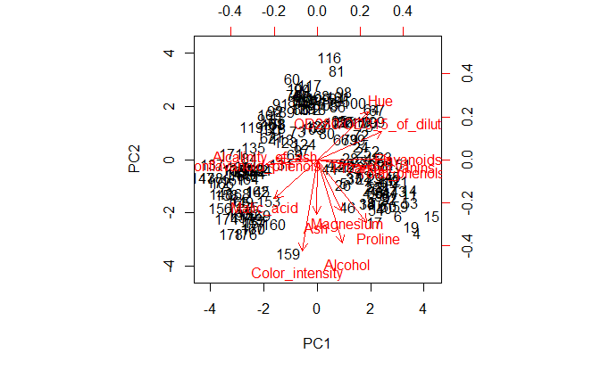

```r
biplot(pca, scale=0)
```

The Feature which lies in the opposite direction to the Hue feature is Malic_acid in the rotated pCA axis.

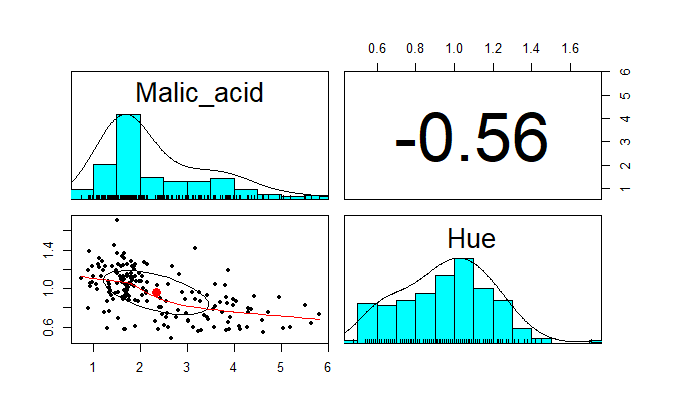

```r
pairs.panels(wine_df[,c(3,12)])
```

From the above figure we can infer that HUE and Malic_Acid are negatively corellated in the original data set with r = -0.56. So as Hue increases, malic_acid decreases. The same can be infered from the rotated pca axis where both lie in the opposite direction.

```r
summary(pca)
```

```
Importance of components:
                         PC1   PC2   PC3    PC4    PC5    PC6    PC7    PC8
Standard deviation     2.169 1.580 1.203 0.9586 0.9237 0.8010 0.7423 0.5903
Proportion of Variance 0.362 0.192 0.111 0.0707 0.0656 0.0494 0.0424 0.0268
Cumulative Proportion  0.362 0.554 0.665 0.7360 0.8016 0.8510 0.8934 0.9202
                          PC9   PC10   PC11  PC12    PC13
Standard deviation     0.5375 0.5009 0.4752 0.411 0.32152
Proportion of Variance 0.0222 0.0193 0.0174 0.013 0.00795
Cumulative Proportion  0.9424 0.9617 0.9791 0.992 1.00000
```

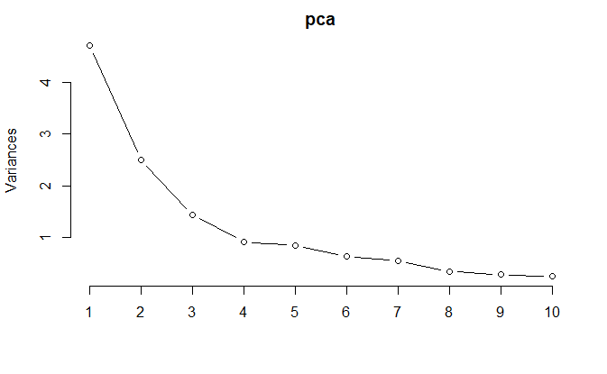

```r
screeplot(pca,type = 'l')
```

Variance explained by PC1 is 0.362 and PC2 is 0.1921. So the total(cumulative) variance explained by PC1 and PC2 is 0.5541.

## Problem 2.2

### Kmeans - Partitional Clustering:

```r
data(USArrests)
head(USArrests)
```

|  | Murder | Assault | UrbanPop | Rape |
| --- | --- | --- | --- | --- |
| Alabama | 13.2 | 236 | 58 | 21.2 |
| Alaska | 10.0 | 263 | 48 | 44.5 |
| Arizona | 8.1 | 294 | 80 | 31.0 |
| Arkansas | 8.8 | 190 | 50 | 19.5 |
| California | 9.0 | 276 | 91 | 40.6 |
| Colorado | 7.9 | 204 | 78 | 38.7 |

We need to scale the data as the features are of different scales.

```r
USArrests <- scale(USArrests)
head(USArrests)
```

```
            Murder Assault UrbanPop      Rape
Alabama    1.24256  0.7828  -0.5209 -0.003416
Alaska     0.50786  1.1068  -1.2118  2.484203
Arizona    0.07163  1.4788   0.9990  1.042878
Arkansas   0.23235  0.2309  -1.0736 -0.184917
California 0.27827  1.2628   1.7589  2.067820
Colorado   0.02571  0.3989   0.8608  1.864967
```

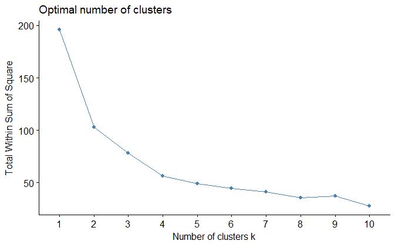

```r
fviz_nbclust(USArrests, kmeans, method="wss")
```

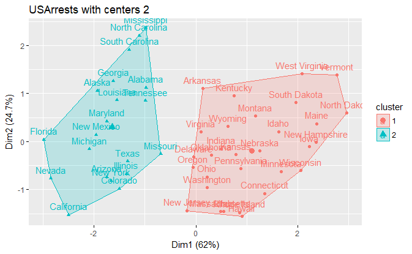

```r
arrest_2 <- kmeans(USArrests,centers=2)
fviz_cluster(arrest_2, data=USArrests, main="USArrests with centers 2")
```

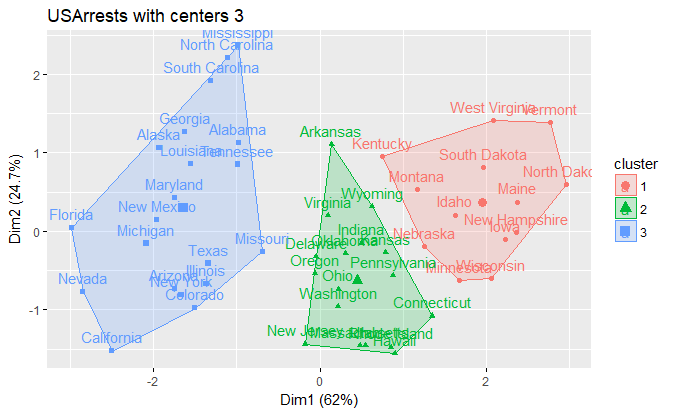

```r
arrest_3 <- kmeans(USArrests,centers=3)
fviz_cluster(arrest_3, data=USArrests, main="USArrests with centers 3")
```

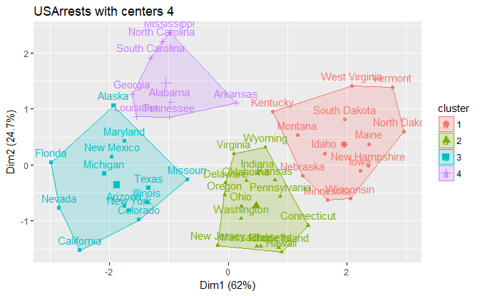

```r
arrest_4 <- kmeans(USArrests,centers=4)
fviz_cluster(arrest_4, data=USArrests, main="USArrests with centers 4")
```

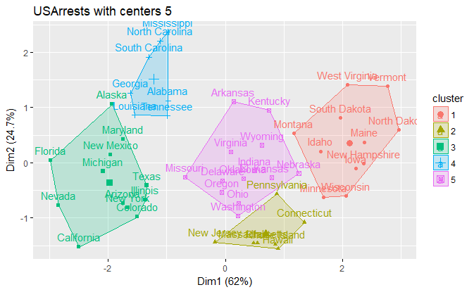

```r
arrest_5 <- kmeans(USArrests,centers=5)
fviz_cluster(arrest_5, data=USArrests, main="USArrests with centers 5")
```

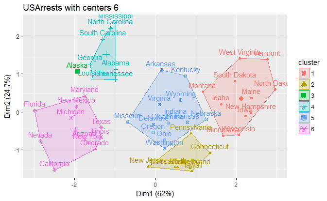

```r
arrest_6 <- kmeans(USArrests,centers=6)
fviz_cluster(arrest_6, data=USArrests, main="USArrests with centers 6")
```

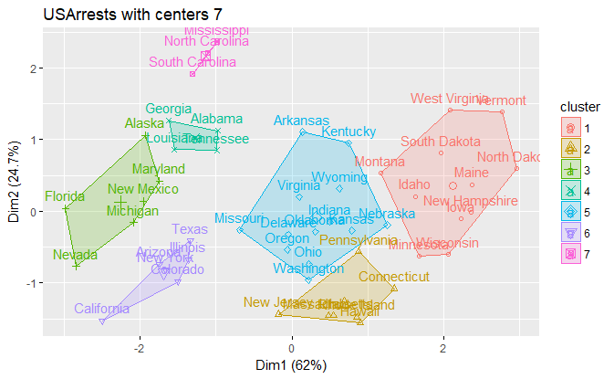

```r
arrest_7 <- kmeans(USArrests,centers=7)
fviz_cluster(arrest_7, data=USArrests, main="USArrests with centers 7")
```

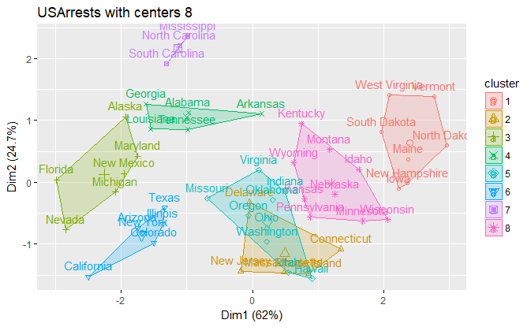

```r
arrest_8 <- kmeans(USArrests,centers=8)
fviz_cluster(arrest_8, data=USArrests, main="USArrests with centers 8")
```

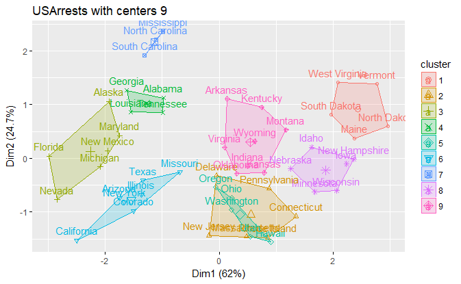

```r
arrest_9 <- kmeans(USArrests,centers=9)
fviz_cluster(arrest_9, data=USArrests, main="USArrests with centers 9")
```

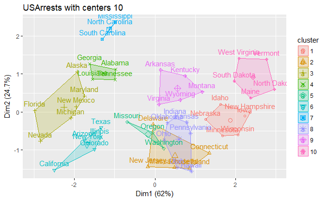

```r
arrest_10 <- kmeans(USArrests,centers=10)
fviz_cluster(arrest_10, data=USArrests, main="USArrests with centers 10")
```

#### Choosing optimal clustring of 4 as the slope dosen’t vary much after k=4. There is minimal decrease in Total within sum of squares after k=4.

#### Optimal Clustering K=4

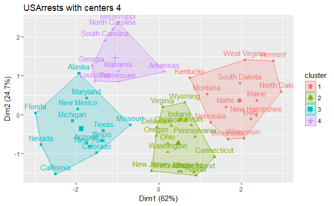

```r
arrest_4 <- kmeans(USArrests,centers=4)
fviz_cluster(arrest_4, data=USArrests, main="USArrests with centers 4")
```

## Problem 2.3

### Hierarchial Clustering:

```r
url_Wine_quality <- "https://archive.ics.uci.edu/ml/machine-learning-databases/wine-quality/winequality-white.csv"
data_wine_quality <- read.csv(url_Wine_quality,header = T,sep=";")
```

```r
head(data_wine_quality[,1:11])
```

|  | fixed.acidity | volatile.acidity | citric.acid | residual.sugar | chlorides | free.sulfur.dioxide | total.sulfur.dioxide | density | pH | sulphates | alcohol |
| --- | --- | --- | --- | --- | --- | --- | --- | --- | --- | --- | --- |
| 1 | 7.0 | 0.27 | 0.36 | 20.7 | 0.045 | 45 | 170 | 1.0010 | 3.00 | 0.45 | 8.8 |
| 2 | 6.3 | 0.30 | 0.34 | 1.6 | 0.049 | 14 | 132 | 0.9940 | 3.30 | 0.49 | 9.5 |
| 3 | 8.1 | 0.28 | 0.40 | 6.9 | 0.050 | 30 | 97 | 0.9951 | 3.26 | 0.44 | 10.1 |
| 4 | 7.2 | 0.23 | 0.32 | 8.5 | 0.058 | 47 | 186 | 0.9956 | 3.19 | 0.40 | 9.9 |
| 5 | 7.2 | 0.23 | 0.32 | 8.5 | 0.058 | 47 | 186 | 0.9956 | 3.19 | 0.40 | 9.9 |
| 6 | 8.1 | 0.28 | 0.40 | 6.9 | 0.050 | 30 | 97 | 0.9951 | 3.26 | 0.44 | 10.1 |

We need to scale the data as the features are in different scales.

#### Complete Linkage:

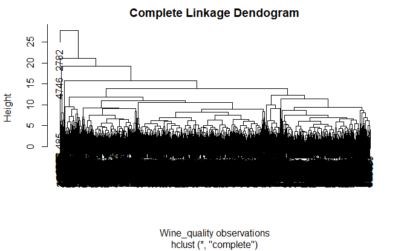

```r
Scale_df_wine_quality <- scale(data_wine_quality[,1:11])
hc.complete <- hclust(dist(Scale_df_wine_quality), method="complete")
plot(hc.complete,main = "Complete Linkage Dendogram",xlab = "Wine_quality observations")
```

#### Single Linkage:

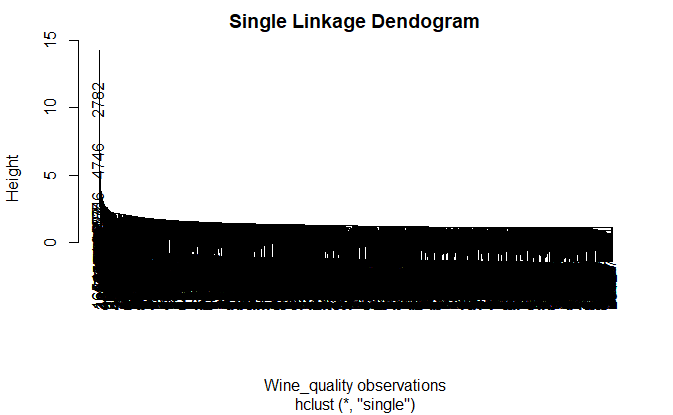

```r
hc.single <- hclust(dist(Scale_df_wine_quality), method="single")
plot(hc.single,main = "Single Linkage Dendogram",xlab = "Wine_quality observations")
```

```r
names(hc.single)
```

```
[1] "merge"       "height"      "order"       "labels"      "method"
[6] "call"        "dist.method"
```

```r
options("digits"=4)
```

```r
tail(hc.single$height,n=1)
```

```
[1] 14.25
```

```r
tail(hc.complete$height,n=1)
```

```
[1] 27.73
```

From the above results we can see that the penultimate clusters are merged at a height of 14.25 and 27.73 for single and complete linkage methods.

```r
H_complete_cut<- cutree(hc.complete,2)
table(H_complete_cut)
```

```
H_complete_cut
   1    2
4897    1
```

```r
H_single_cut<- cutree(hc.single,2)
table(H_single_cut)
```

```
H_single_cut
   1    2
4897    1
```

```r
data_wine_quality$Clusters <- H_single_cut
data_wine_quality <- dplyr::group_by(data_wine_quality,Clusters)
single_summary <- dplyr::summarise_each(data_wine_quality, funs(mean))
```

```
`summarise_each()` is deprecated.
Use `summarise_all()`, `summarise_at()` or `summarise_if()` instead.
To map `funs` over all variables, use `summarise_all()`
```

```r
print.data.frame(single_summary)
```

| Clusters | fixed.acidity | volatile.acidity | citric.acid | residual.sugar | chlorides | free.sulfur.dioxide | total.sulfur.dioxide | density | pH | sulphates | alcohol | quality |
| --- | --- | --- | --- | --- | --- | --- | --- | --- | --- | --- | --- | --- |
| 1 | 6.855 | 0.2781 | 0.3341 | 6.379 | 0.04577 | 35.31 | 138.4 | 0.994 | 3.188 | 0.4898 | 10.51 | 5.878 |
| 2 | 7.800 | 0.9650 | 0.6000 | 65.800 | 0.07400 | 8.00 | 160.0 | 1.039 | 3.390 | 0.6900 | 11.70 | 6.000 |

```r
data_wine_quality$Clusters <- H_complete_cut
data_wine_quality <- dplyr::group_by(data_wine_quality,Clusters)
complete_summary <- dplyr::summarise_each(data_wine_quality, funs(mean))
```

```
`summarise_each()` is deprecated.
Use `summarise_all()`, `summarise_at()` or `summarise_if()` instead.
To map `funs` over all variables, use `summarise_all()`
```

```r
print.data.frame(complete_summary)
```

| Clusters | fixed.acidity | volatile.acidity | citric.acid | residual.sugar | chlorides | free.sulfur.dioxide | total.sulfur.dioxide | density | pH | sulphates | alcohol | quality |
| --- | --- | --- | --- | --- | --- | --- | --- | --- | --- | --- | --- | --- |
| 1 | 6.855 | 0.2781 | 0.3341 | 6.379 | 0.04577 | 35.31 | 138.4 | 0.994 | 3.188 | 0.4898 | 10.51 | 5.878 |
| 2 | 7.800 | 0.9650 | 0.6000 | 65.800 | 0.07400 | 8.00 | 160.0 | 1.039 | 3.390 | 0.6900 | 11.70 | 6.000 |

Residual.sugar feature has the largest cluster mean difference as observed from the above results.

From the above results and Dendogram graphs we can say that Complete Linkage method dendogram is much more balanced than the Single Linkage Dendogram.